# Applied Statistics for Life Scientists — Session 2

## My p-value is 0.09. What should I do?

Give the researcher one piece of advice

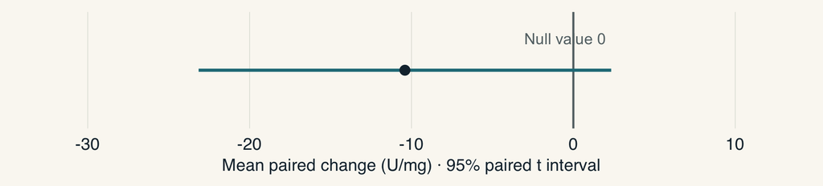

**−10.4 U/mg** · 95% CI **−23.2 to +2.3** · p = **0.090**

L1 · compound Q versus vehicle · six independent preparation pairs

## Why is the answer still unclear?

EffectZero, small, or biologically relevant?

SamplingAn imprecise experiment by chance?

BiologyLarge preparation-to-preparation variation?

ReplicationFew independent preparations?

DesignAvoidable sources of variation?

ModelDoes the analysis match the experiment?

The p-value alone cannot choose between these explanations.

## Suppose the true mean effect is −14 U/mg

Predict · discuss with a neighbour

Same L1 protocol. Six new preparation pairs.  
True mean effect fixed at **−14 U/mg**.

Would every repetition give p < 0.05?

Same variability and paired t analysis.  
Two-sided decision rule fixed in advance: p < 0.05.

A teaching assumption from the original population model—not a conclusion from our p-value.

## Same biology, different experiments

Inspect both experiments · 1 minute

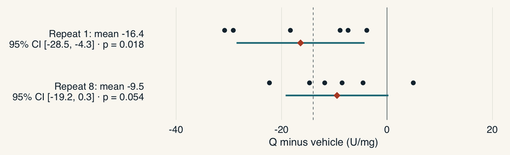

How can both arise from the same true mean effect?

Illustrative contrast: first rejection and first non-rejection selected from the simulation. Dashed line: true mean −14; solid line: 0.

## What proportion would cross the threshold?

Estimate the share of crosses before the reveal

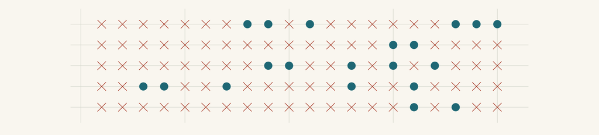

**78%** crossed p < 0.05 across 10,000 repetitions.

**Power = P(reject H<sub>0</sub> | a specified alternative is true)**

Rust crosses reject; teal dots do not. First 100 shown in order; true mean −14 in every repetition.

## When a real effect does not cross the threshold

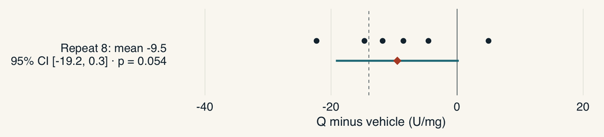

**Type II error:** not rejecting H<sub>0</sub> when the specified alternative is true

β ≈ 22% here · Power = 1 − β

We can identify this simulated error because we know the simulated truth.

## Can we conclude that Q has no effect?

Discuss · 1 minute

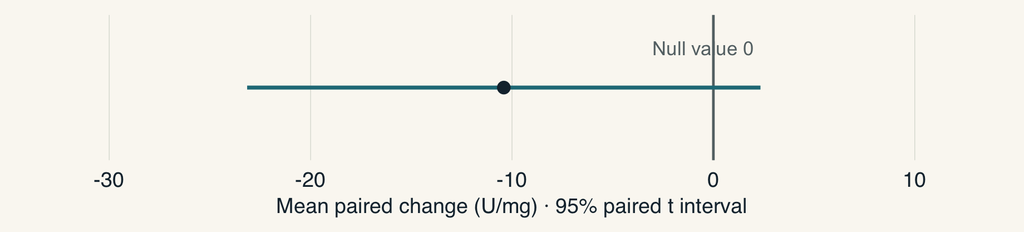

Our actual result: mean −10.4 · 95% CI −23.2 to +2.3 U/mg · p = 0.090

Zero, small effects and substantial reductions remain compatible.

This is uncertainty about the mean effect, not proof of absence.

## p > α does not mean no effect

Key message

Our interval: −23 to +2 U/mg.

It includes zero — and a reduction  
of almost a quarter of enzyme activity.

Absence of evidence is not evidence of absence.

## What would change that proportion?

Predict each change before the next reveal

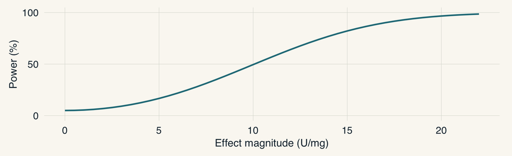

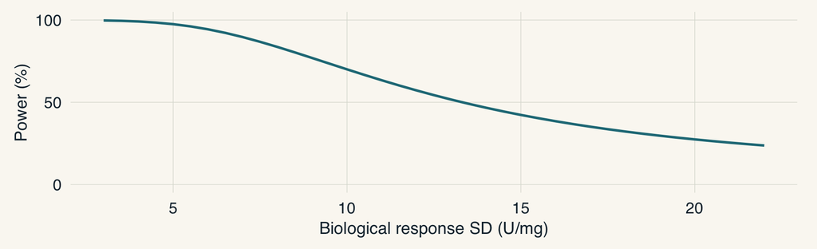

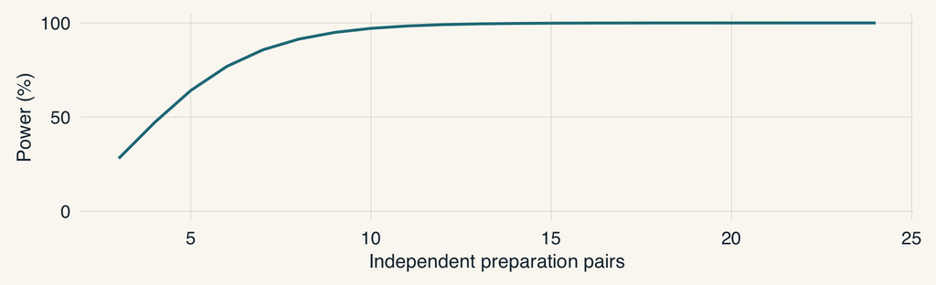

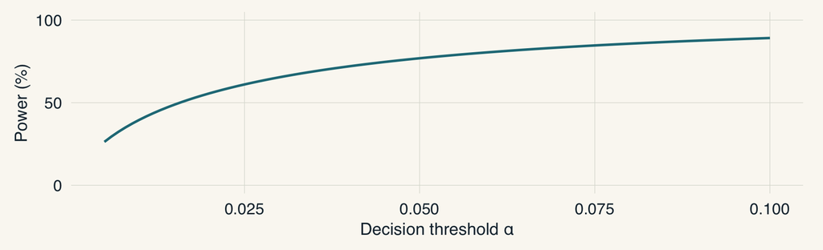

Vary one assumption at a time: effect, biological variability, independent N, then alpha. Other settings stay fixed.

## What effect is worth detecting?

Decide · then defend your threshold

### What we observed

−10.4 U/mg  
from six preparations

### What would matter

A minimum relevant effect  
justified by the biology

“How many replicates?” comes after “What question must they answer?”

## How noisy is the biology?

Technical readingsHow repeatable is the assay?

Preparation responsesHow differently do new cultures respond?

Day / batchWhat do observations share?

Systematic variationWhat belongs in the design or model?

Plan with the variability of the **paired changes**.

## Does doubling N halve the uncertainty?

Predict before the reveal

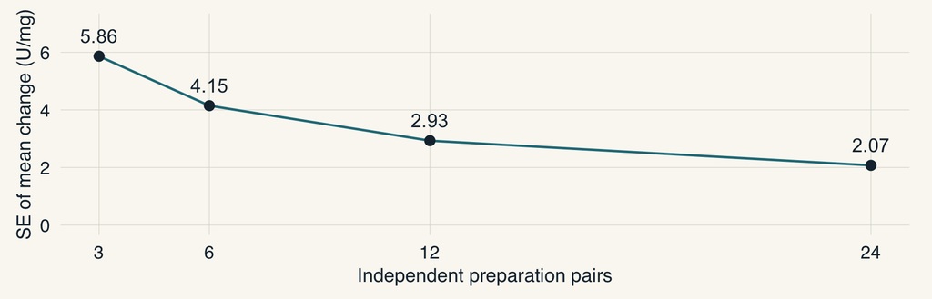

SE ∝ 1 / √n · doubling n multiplies SE by about 0.71

Independent pairs under the same model. More pairs do not repair bias, confounding or a restricted sampling frame.

## Can a better comparison remove irrelevant variation?

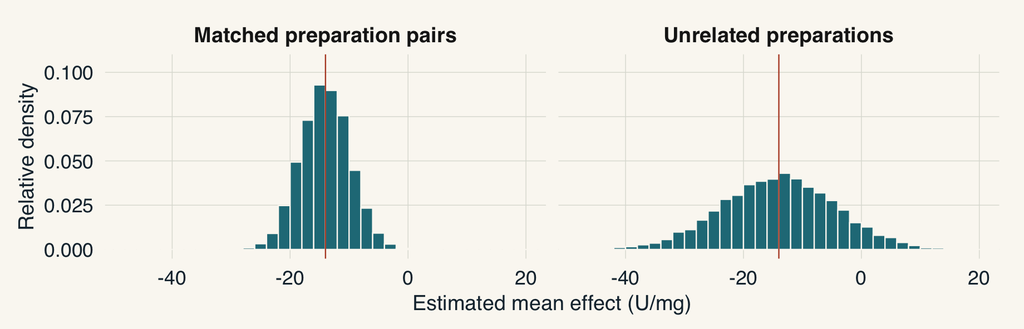

Shared preparation variation cancels in a meaningful paired contrast.

Same 12 culture tubes, true mean −14 and balanced conditions across days. Pairing must reflect a real shared source.

## Where should six additional assay wells go?

Choose, then explain what your choice buys

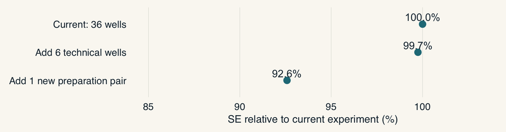

Technical repeats improve measurement precision and assay checks.  
New preparations add information about population responses.

42 assay wells in either option. A new pair also requires new culture work; total costs are not equal.

## What must we specify before calculating N?

Question and quantityWhich effect, in which experimental space?

Experimental unitWhat counts as independent replication?

Relevant effectWhat magnitude is worth detecting?

Expected variationHow variable are the paired responses?

Design and analysisHow will allocation, blocking and pairing work?

Decision and targetWhich alpha and desired power?

Only then does a sample-size calculation make sense.

## How many pairs does your experiment need?

Find your experiment’s number in the grid

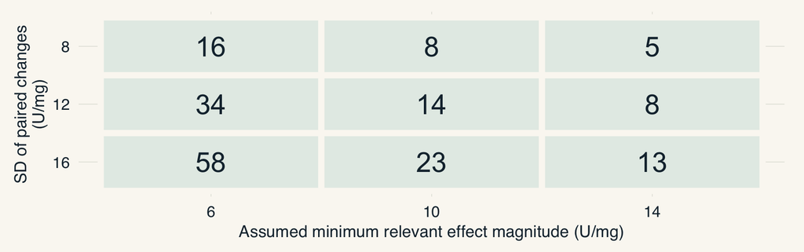

Numbers are required **independent preparation pairs**.

Illustrative assumptions: paired t analysis, 80% target, two-sided α = 0.05. These are conventions, not requirements or an L1 recommendation.

## My p-value is 0.09. What should I do now?

Revise your earlier advice · 1 minute

### Inform the next experiment

Interpret the effect and interval.  
Replicate independently if justified.  
Improve design and reduce avoidable variation.  
Plan independent N and analysis in advance.

### Do not chase the threshold

Switch analysis only to get p < 0.05.  
Delete observations just for a smaller p.  
Choose one-sided after seeing direction.  
Keep adding samples until p crosses.

## Design for a useful answer

Biological effect + variation  
+ experimental design + independent N  
↓Precision  
↓Probability of crossing a pre-specified decision threshold

The last step also depends on alpha and the planned analysis; crossing a threshold alone does not settle the biological question.

Power is primarily prospective.  
How can the next experiment answer the biological question with useful precision?

## One question to carry forward

Suppose I measured 20 outcomes and only one gave p < 0.05. What now?

## We measured 20 outcomes. One gave p = 0.03.

The L1 experiment now measures 20 markers

Is p = 0.03 still p = 0.03?

The individual number is unchanged.  
The opportunity to find a small number has changed.

Hypothetical expansion of the assay—not a revision of the observed enzyme result, p = 0.090.

## What happens when none of the markers responds?

Predict before the next experiments appear

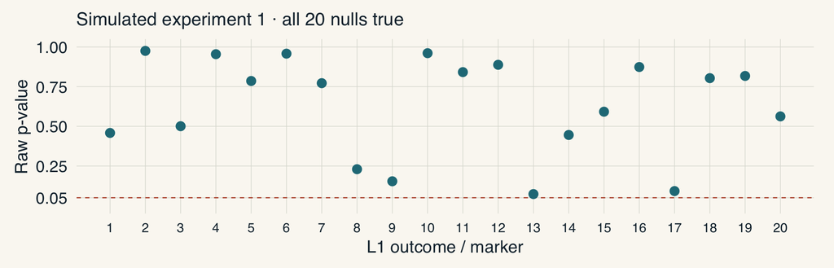

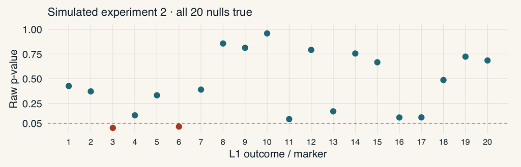

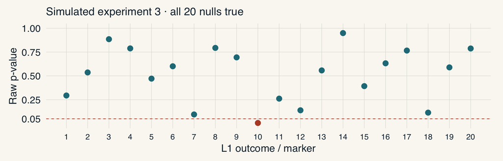

Would one value below 0.05 surprise you?

Six paired changes per marker. Independent markers, all nulls true. First three simulated experiments, unselected.

## How many chances did we give ourselves?

Predict: how many experiments find at least one?

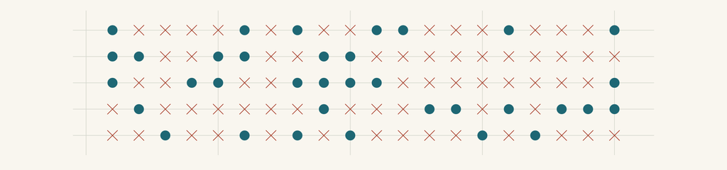

**64.27%** of 10,000 experiments found at least one.

Under independence: 1 − (1 − 0.05)<sup>20</sup> ≈ 0.64

One symbol = one 20-test experiment. A 5% per-test rate is not a 5% any-error rate.

## Which claims belong to the same family?

What shared claim would make these one family?

20 prespecified cytokines  
Several treatment contrasts

Multiple time points  
Several primary endpoints

**Family-wise error rate (FWER)**

Probability of at least one Type I error within a defined family of hypotheses

The family follows the scientific claims and decision—not whichever results look interesting.

## What if we measured 20,000 genes?

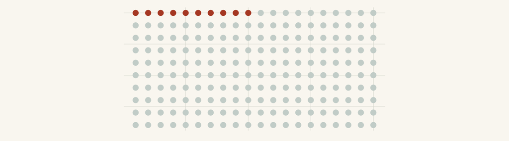

20,000 × 0.05 = **1,000 expected raw false positives**

All nulls true; valid exact 5% tests. Each dot represents 100 genes. Illustration of an expectation—not one observed screen.

## What error promise fits a discovery list?

New simulation: 4 nonzero marker effects + 16 true nulls; independent tests.

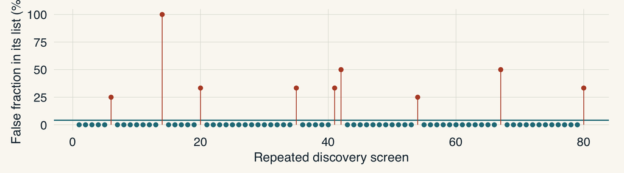

**FDR:** expected false-discovery proportion over repeated use

Line: mean false fraction 4.1% across 10,000 screens. No discoveries → fraction 0.  
One dataset’s fraction is not guaranteed to equal the target.

## Which promise does the scientific question need?

### Confirmatory family

How likely is even one false rejection?  
**FWER**

### Exploratory candidate list

What false fraction is controlled on average?  
**FDR**

Choose the error criterion from the scientific purpose.

In our mixed simulation, controlling FDR kept the average false fraction at 4.1% — but at least one false hit still occurred in 10.2% of screens.

## You report p = 0.03. What else did you try?

Name one hidden opportunity from your own work

20 endpoints

Several doses

Several time points

Several subgroups

Different exclusion rules

Transformed or untransformed outcome

Paired or unpaired analysis

One-sided or two-sided test

Stopping or adding observations after a look

Multiple opportunities can be visible—or hidden in analytical choices.

## The test direction must be specified before seeing the data

### Planned one-sided

Direction fixed before collection: only a reduction is biologically plausible.

α = 0.05 on one tail. Legitimate.

### Post-hoc one-sided

Direction chosen after seeing the effect is negative: “clearly it’s a reduction, so one-sided.”

Two-sided p = 0.090 → one-sided p = 0.045. The α = 0.05 promise was not what was kept.

Choosing the direction after looking is a hidden extra test.

## A pause before we examine selection

15-minute break

Next: exploration vs confirmation.

## Exploration is useful science

Key message

Explore → generate a hypothesis  
→ independently test it

A p-value from exploratory data means little:  
the hypothesis came from the same data.

Show which ideas emerged from the data — and test them in a new experiment.

## What does the reader learn from these two reports?

Compare reports A and B · 1 minute

### Report A

“Outcome X was significantly affected, p = 0.03.”

### Report B

“We examined 20 prespecified outcomes. X had raw p = 0.03; the full family, effect estimates, intervals and planned multiplicity analysis are reported.”

Same raw p-value. A different view of how it was found.

## What can we decide before the data arrive?

PurposeConfirmatory or exploratory?

OutcomesPrimary, secondary and their families

ComparisonsPlanned contrasts and time points

Included dataAnalysis population and exclusion rules

StoppingWhen is collection complete?

Error promiseMultiplicity strategy and analysis

Prespecification makes the claim and its error guarantee interpretable.

## One question to carry forward

Fine. But which statistical test should I actually use for my experiment?

## Which statistical test should I use?

What information is missing?

Biological question?

Experimental unit?

Measured outcome?

Comparison of interest?

Related observations?

Experimental design?

The name of the test comes late.

## What are we trying to learn about Q?

Mean change in enzyme activity caused by Q  
within independently initiated L1 preparations.

Scientific question → design → quantity of interest  
→ statistical model → estimate, interval and test

L1 · 10 µM Q versus vehicle · 24 hours · Q − vehicle

## What did the instrument—or observer—record?

Classify your own endpoint · then reveal

**Continuous**  
Activity · fluorescence · expression

**Binary**  
Alive/dead · response/no response

**Count**  
Colonies · mutations · events

**Time to event**  
Time until death or differentiation

The outcome’s structure shapes the model.

## 120 cells. What is N?

What is missing from the row count?

Donors? → cultures → wells → cells

Where was Q assigned?  
Which units were independently generated?

The row count cannot answer this.

## Metadata decide the analysis

Key message

Record preparation, day, tube and well  
for every value.

Without metadata nobody — including you in six months — can reconstruct the design, find N, or choose the right analysis.

## Do independently treated cultures differ on average?

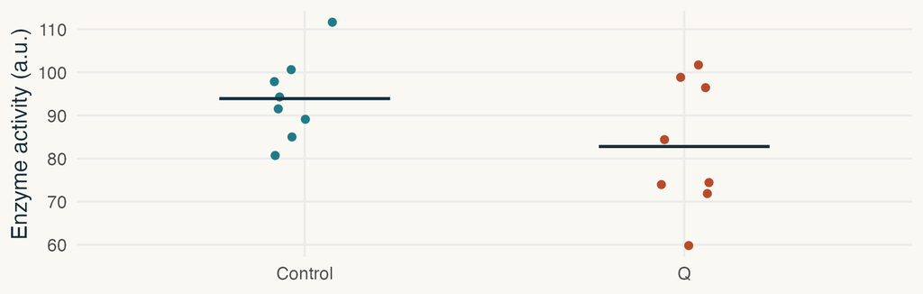

Q − control: **−11.1 U/mg** · 95% CI −24.9 to 2.7

Welch’s two-sample t-test · unequal variances allowed

New simulated experiment: 8 independently generated cultures per group; randomized assignment.

## The design created pairs

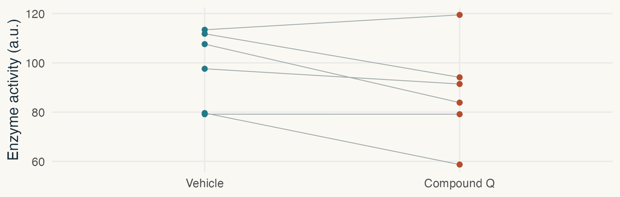

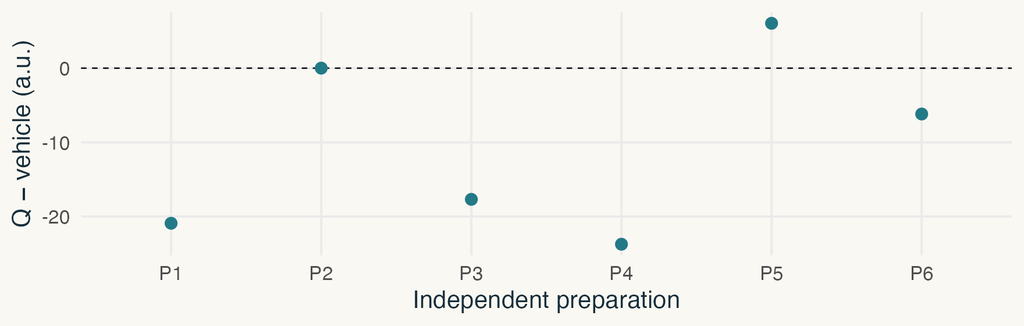

One preparation → control and Q → one difference

Paired t-test = one-sample t-test on the six differences.

Original L1 data: mean difference −10.4 U/mg; 95% CI −23.2 to +2.3.

## Same measurements. Same analysis?

Predict: does the interval change? · then reveal

**A** Six control cultures + six unrelated Q cultures

**B** Six preparations, each split into control and Q

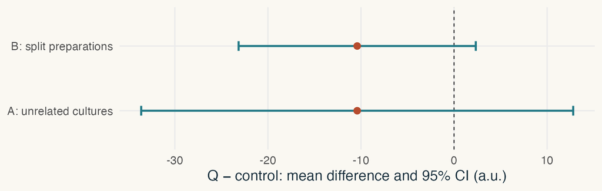

The spreadsheet columns do not tell us the design.

Counterfactual comparison using the same values. The actual L1 experiment is B.

## Pairing and blocking buy power

Key message

Paired and blocked designs have higher power:  
the same N gives a more precise answer.

Same L1 values: analysed as unrelated groups, 95% CI −33.6 to +12.8; as the paired design they came from, −23.2 to +2.3. Plan pairs or blocks when a shared source of variation exists — and analyse them as such.

## Four doses: should we run six separate tests?

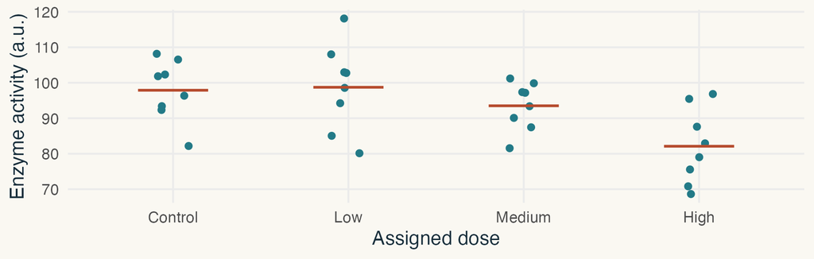

Represent the group means together in one model.

ANOVA belongs to the linear-model framework.

Simulated independent cultures · 8 per group · continuous activity.

## What would we want to know about these doses?

Choose a question · then name its effect

Any difference among means?

Each dose versus control?

A dose-response trend?

High dose versus low dose?

An omnibus test asks whether all group means can be equal.

Planned contrasts answer specific questions. Several contrasts may require multiplicity control.

## Does Q have the same effect in both genotypes?

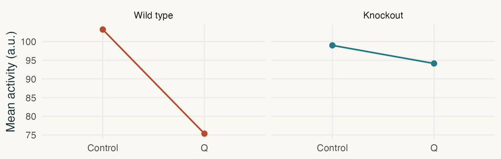

Interaction: does the Q effect depend on genotype?

Compare the effects—not their significance labels.

Simulated independent cultures · genotype × treatment · 8 cultures per cell.

## Simple designs need fewer replicates

Key message

Every extra group or factor costs replicates.  
One clear comparison is the most powerful design.

Detecting an interaction of the same size as a single treatment effect needs about four times as many replicates.

## Time-course experiments: showing the effect vs. testing it

Discuss with a neighbour · 2 minutes

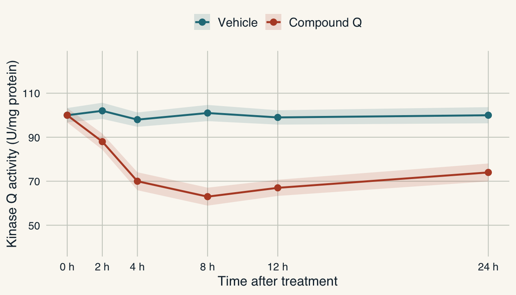

Each preparation is split into tubes; one Vehicle and one Q tube are harvested at each time point.

Time points from the same preparation share its biology — they are not independent comparisons.

Two-way ANOVA on time × treatment treats them as if they were.

## A time-course is most honest as exploration

**Explore**

Show the curve. Report no p-value.  
You are watching biology unfold.

**Pre-specify one time point**

Decide before seeing the data.  
Test that one point. If several points were planned, correct for multiple testing (e.g. Holm).

**Summarise the curve**

AUC or kinetic parameter per unit  
→ one number per preparation → t-test that.

If testing, collapse the curve to one number per unit first.

## In any of these designs — what is one independent observation?

The analysis follows the experimental unit,  
not the measurement count.

Before choosing a test, identify what was truly independently repeated.

## Do 100 cells from one culture give N = 100?

One culture → shared conditions → 100 cell measurements

More rows do not necessarily mean more independent information.

Summarize at the experimental-unit level, when appropriate

Model clustering or repeated measurements explicitly

## Does a normality test tell you which analysis to use?

Vote before the reveal

Shapiro–Wilk p > 0.05  
↓  
t-test?

Shapiro–Wilk p < 0.05  
↓  
Mann–Whitney?

No: this is not a sound automatic decision rule.

The normality assumption applies to the **population** — not to whether your sample looks bell-shaped.

Small N can hide important departures.  
Large N can detect practically unimportant departures.

## What must be credible for inference about a mean?

Independent experimental units

A quantitative outcome and meaningful mean

Adequate sampling model

No unaddressed influential problems

For paired inference, assess the **differences**.

Welch allows unequal group variances. Normality is not an absolute requirement for every use of t inference.

## If the data are not normal, automatically use ranks?

Does that still answer our biological question?

**t inference**  
A difference in population means

**Mann–Whitney**  
A rank-based distributional comparison

A location-shift interpretation needs additional assumptions.

Neither a universal test of medians nor an assumption-free replacement.

## Delete it? Transform? Switch the test?

What evidence would you seek first?

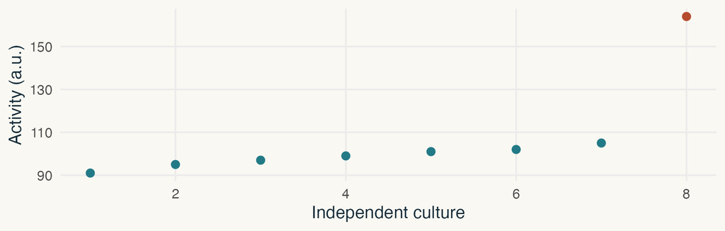

First investigate why the observation is extreme.

Recording error? Prespecified QC failure? Biology? Model mismatch?

## What must an analysis plan connect?

Apply to the L1 assay · 1 minute

1 · Biological quantity

2 · Experimental unit

3 · Outcome type

4 · Independence, pairing, clustering

5 · Conditions and factors

6 · Planned comparisons

7 · A reasonable model

8 · Effect estimate and uncertainty

**9 · Test, if needed**

10 · Multiplicity

A reasoning checklist—not an automatic test-selection tree.

## Where do familiar procedure names fit?

| Situation | Quantity | Possible framework |
| --- | --- | --- |
| Continuous · independent groups | Mean difference | Welch t / suitable linear model |
| Continuous · paired | Mean paired difference | Paired t / model of differences |
| Continuous · several groups | Group mean contrasts | Linear model / ANOVA |
| Several factors | Effects and interactions | Factorial model |
| Binary | Risk difference, ratio or odds | Binomial / logistic; suitable Fisher exact question |
| Counts | Count or rate comparison | Count model with suitable exposure/dispersion |
| Clustered / repeated | Design-specific effect | Dependence model; often mixed effects |

Orientation, not an exhaustive menu or a selection algorithm.

## Tell me how you did the experiment—and what you want to learn.

Before recommending an analysis, what would you ask?

Which statistical test should I actually use?

Test selection follows understanding the experiment.

Now design an experiment that statistics will not have to rescue.

## Five issues you will see in almost every paper

1Multiplicative vs additive effects

2Truncated y-axis

3Wide-range data and axis breaks

4Unlabelled error bars

5Individual data hidden by summaries

Recognising these makes you a better reader — and a better author.

## When the effect is multiplicative, use the log scale

Predict: how do 3-fold up and 3-fold down look? · then reveal

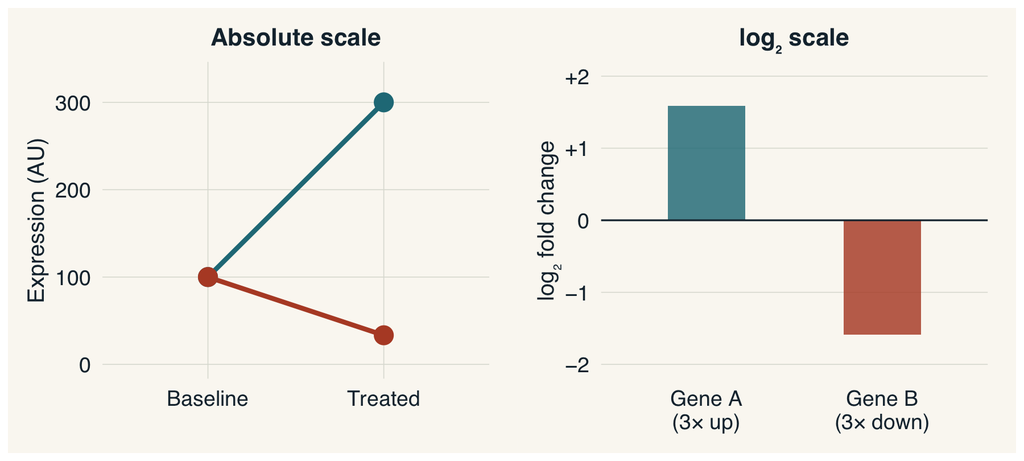

A fold change is already a ratio — the log scale treats equal folds equally.

Left: absolute scale. Three-fold up = +200; three-fold down = −67. Asymmetric on this scale. Right: log₂ fold change. Both are ±1.58. RNA-seq log₂ fold change applies this directly. For the L1 enzyme assay, absolute differences are appropriate — effects are small and baselines similar.

## What does chopping the y-axis do?

Which panel shows the larger effect? · 1 minute

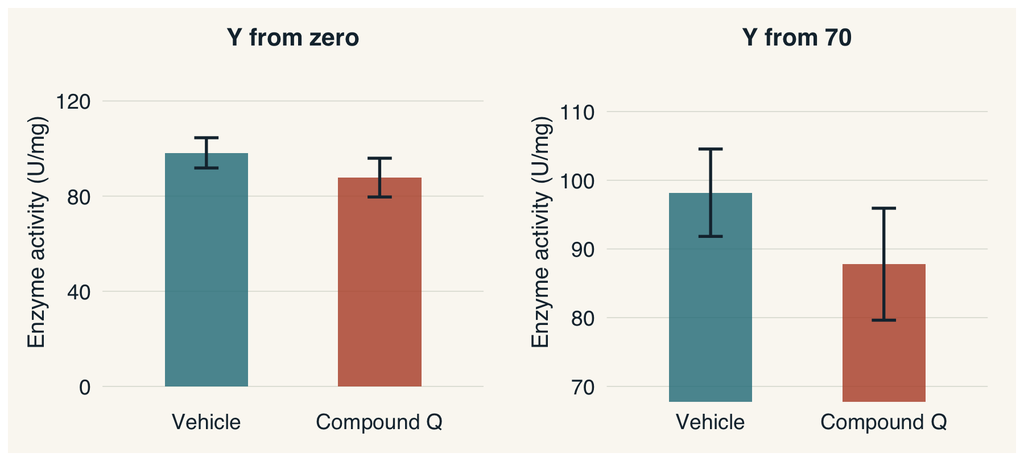

Same data. A bar chart encodes length from zero — a truncated axis is a visual distortion.

Both panels show the same L1 enzyme experiment. A dot plot or line plot with a marked non-zero baseline can legitimately start elsewhere; a bar chart cannot.

## When values span orders of magnitude

Which panel lets you compare all four conditions? · 1 minute

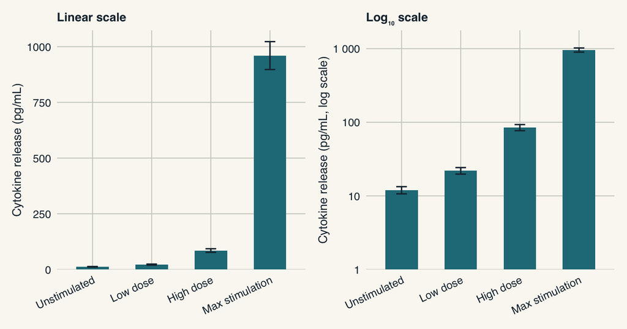

An axis break removes the middle of the scale — log scale preserves it.

Publications often use a gap symbol (⁄⁄) to skip the empty middle of the y-axis. This hides how far apart the values really are. Log scale is the honest alternative when effects are proportional.

## Many lab measurements belong on a log scale

Key message

Fluorescence, RNA and protein levels, cytokines, counts:  
analyse and plot them on a log scale.

These quantities change by factors, not fixed amounts, and their spread grows with their level. On the log scale fold changes become symmetric and comparable.

## Three error bars. Three different claims.

Which is SD, SEM, 95% CI? · then reveal

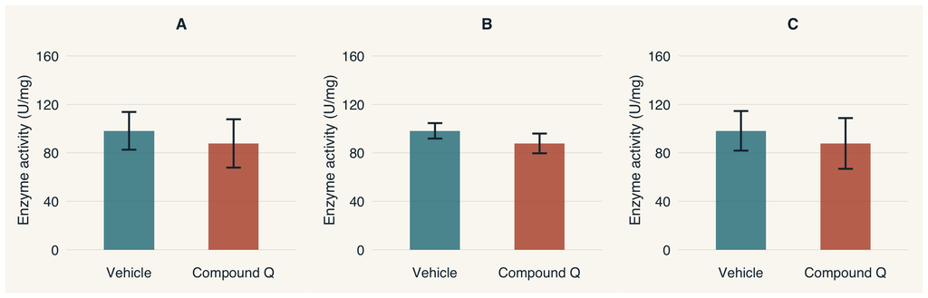

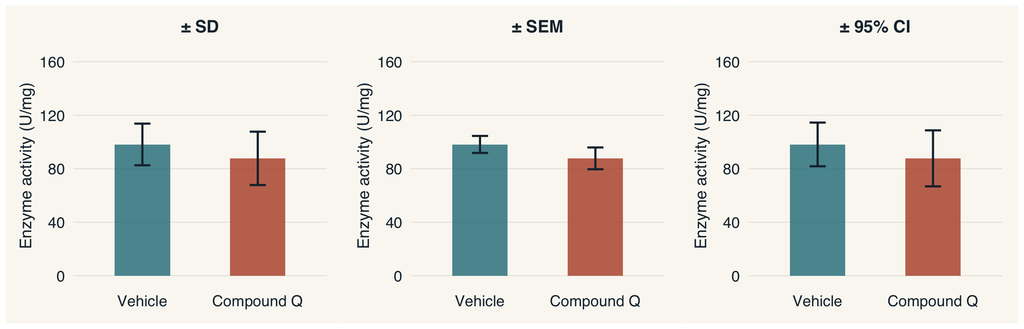

An unlabelled error bar tells you nothing. Label it — or the reader has to guess.

Same six L1 preparations throughout. SD: spread of individual preparations. SEM: precision of the group mean. 95% CI: range of effect sizes compatible with the data. Each answers a different question.